# Homework 2

## Linear regression with a numerical predictor

Linear model is in the form $\hat{y} = b_0 + b_1 x$.

- **2e.** Let’s see if the apparent trend in the plot is something more than natural variation. Fit a linear model called `m_core` to predict average `overal` ratings by average core dimensions (`core_avg`). Based on the regression output, write the linear model.

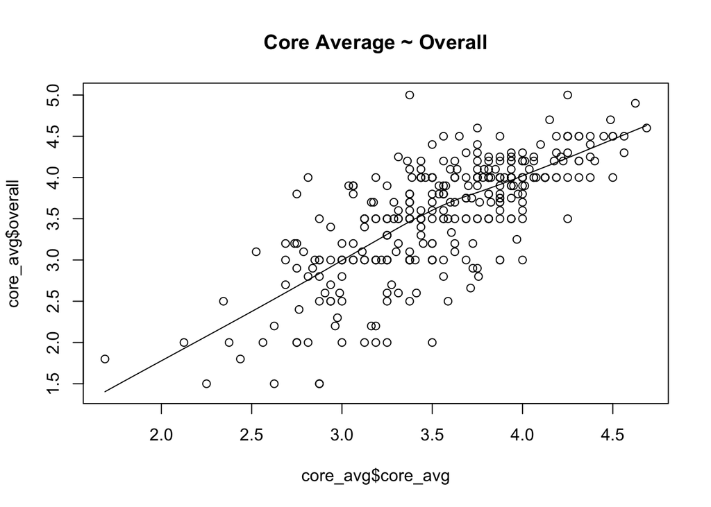

```r
scatter.smooth(x=core_avg$core_avg, y=core_avg$overall, main="Core Average ~ Overall")
```

```r
m_core<- lm(core_avg$overall ~ core_avg$core_avg, data=burrito)
print(m_core)
```

```
##
## Call:
## lm(formula = core_avg$overall ~ core_avg$core_avg, data = burrito)
##
## Coefficients:
##       (Intercept)  core_avg$core_avg
##            -0.144              1.042
```

```r
#the linear regression has equation y=1.042x-0.144
summary(m_core)
```

```
##
## Call:
## lm(formula = core_avg$overall ~ core_avg$core_avg, data = burrito)
##
## Residuals:
##     Min      1Q  Median      3Q     Max
## -1.5020 -0.2415  0.0423  0.2726  1.6282
##
## Coefficients:
##                   Estimate Std. Error t value Pr(>|t|)
## (Intercept)        -0.1442     0.1894   -0.76     0.45
## core_avg$core_avg   1.0418     0.0527   19.78   <2e-16
##
## Residual standard error: 0.47 on 326 degrees of freedom
## Multiple R-squared:  0.545,  Adjusted R-squared:  0.544
## F-statistic:  391 on 1 and 326 DF,  p-value: <2e-16
```

- **2f.** Replot your visualization from **2c.**, and add the regression line to this plot in orange color. Turn off the shading for the uncertainty of the line.

  **Hint:** use argument `method=‘lm’` to plot the linear fit, use `se=False` to turn off the uncertainty shading

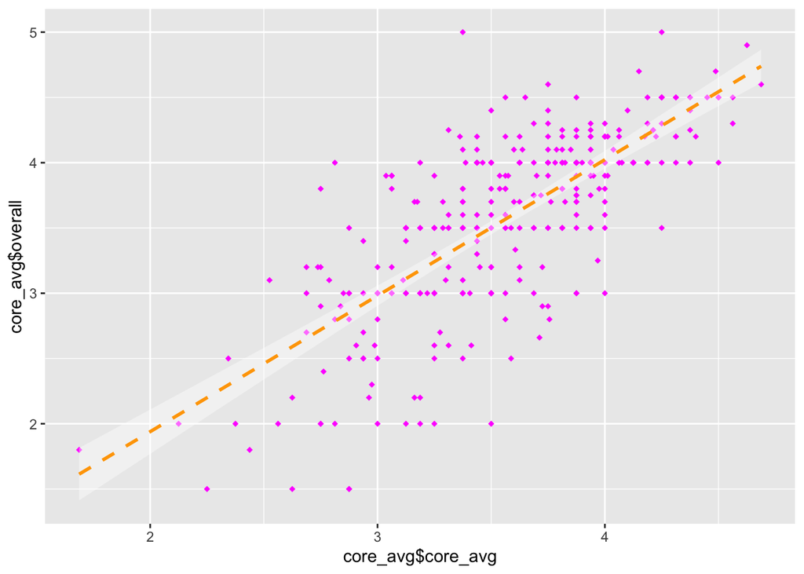

```r
#scatter<-scatter.smooth()

ggplot(burrito, aes(x=core_avg$core_avg, y=core_avg$overall, main="Core Average ~ Overall")) +
  geom_point(shape=18, color="magenta")+
  geom_smooth(method=lm,  linetype="dashed",
            color="orange", fill="transparent")
```

- **2g.** Interpret the slope of the linear model in context of the data.
- **2h.** Interpret the intercept of the linear model in context of the data. Comment on whether or not the intercept makes sense in this context.

## Linear regression with a categorical predictor

- **2i.** Fit a new linear model called `m_rec` to predict average `overall` ratings based on `Rec` whether the reviewer recomends it or not. Based on the regression output, write the linear model and interpret the slope and intercept in context of the data.

```r
#2g) The slope of the linear model is positive.
#This shows that there is a positive relationship between core_avg and overall.

#2h) The fact that the y intercept is basically zero makes sense.
#It means that even if youre core average is zero your
#overall score will also be basically zero. It makes sense
#since core_avg and overall are very similar concepts.


#2i)
#If recommended:
m_recyes<- lm(core_avg$overall ~ core_avg$Rec=="Yes", data=burrito)
print(m_recyes)
```

```
##
## Call:
## lm(formula = core_avg$overall ~ core_avg$Rec == "Yes", data = burrito)
##
## Coefficients:
##               (Intercept)  core_avg$Rec == "Yes"TRUE
##                      2.87                       1.03
```

```r
#              (Intercept)  core_avg$Rec == "Yes"TRUE
#                     2.87                       1.03
#If not recommended:"
m_recno<- lm(core_avg$overall ~ core_avg$Rec!="Yes", data=burrito)
print(m_recno)
```

```
##
## Call:
## lm(formula = core_avg$overall ~ core_avg$Rec != "Yes", data = burrito)
##
## Coefficients:
##               (Intercept)  core_avg$Rec != "Yes"TRUE
##                      3.90                      -1.03
```

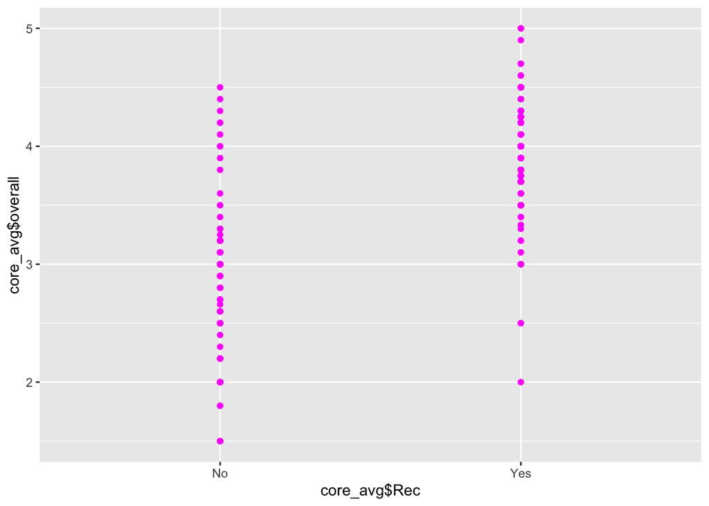

```r
#(Intercept)  core_avg$Rec == "No"TRUE
#   3.90                     -1.03
#This shows that a recommended burrito will have a higher
#score on average than a non-recommended burrito.
#For any given value of x, the regression formula is such
#that the former will be higher than the latter.

ggplot(burrito, aes(x=core_avg$Rec, y=core_avg$overall, main="Core Average ~ Overall")) +
  geom_point(color="magenta")+
  geom_smooth(method=lm,  linetype="dashed",
            color="orange", fill="orange")
```

```r
#You can see by the plot that recommended burritos have higher overall scores.
```

- **2j.** What is the equation of the line corresponding to burritos that are recommended ? What is it for non-recommended burritos?
- **Challenge** Create a new variable called `CaliBurrito` that labels `Burrito` has string `'california'` in it as “Yes” and all other burrito types as “No”.

```r
#Challenge 1
CaliBurrito <- burrito %>%
  mutate(CaliBurrito = ifelse(Burrito=="california","Yes","No"))
print(CaliBurrito)
```

```
## # A tibble: 328 x 16
##    Location Burrito Hunger Tortilla  Temp  Meat Fillings MeatToFilling
##    <chr>    <chr>    <dbl>    <dbl> <dbl> <dbl>    <dbl>         <dbl>
##  1 senor g… califo…    2        2     3.5   3        1.5           1
##  2 roberto… chicke…    2        1.5   4     2        2             4.5
##  3 lucha l… holy m…    3        2.5   2.5   3        2             2
##  4 lucha l… ala ti…    3        3     2.5   3.5      3             1
##  5 senor g… pastor     2        2.5   2.5   1.5      2.5           1
##  6 goody's  custom     3.5      1.5   1     2        2             2
##  7 jv's me… carne …    3.5      2.5   1.5   1.5      3             4.5
##  8 tony's … batter…    3        3     1     1.5      2.5           4
##  9 los pri… califo…    2.5      3     4     3        2             1.5
## 10 los pri… baja m…    4        3     3     1        4             2
## # … with 318 more rows, and 8 more variables: Uniformity <dbl>,
## #   Salsa <dbl>, Wrap <dbl>, Cost <dbl>, Reviewer <chr>, Rec <chr>,
## #   overall <dbl>, CaliBurrito <chr>
```

- **Challenge** Fit a new linear model called `m_cali` to predict average ratings `overall` based on `CaliBurrito`, `core_avg` and their interaction. This is the new variable you created in 12. Based on the regression output, write the linear model and interpret the coefficients in context of the data. Also determine and interpret the adjusted $R^2$ of the model.

```r
str(CaliBurrito)
```

```
## Classes 'spec_tbl_df', 'tbl_df', 'tbl' and 'data.frame': 328 obs. of  16 variables:
##  $ Location     : chr  "senor grubby's" "roberto's very mexican food" "lucha libre north park" "lucha libre carlsbad" ...
##  $ Burrito      : chr  "california" "chicken asada" "holy moly" "ala tingada california" ...
##  $ Hunger       : num  2 2 3 3 2 3.5 3.5 3 2.5 4 ...
##  $ Tortilla     : num  2 1.5 2.5 3 2.5 1.5 2.5 3 3 3 ...
##  $ Temp         : num  3.5 4 2.5 2.5 2.5 1 1.5 1 4 3 ...
##  $ Meat         : num  3 2 3 3.5 1.5 2 1.5 1.5 3 1 ...
##  $ Fillings     : num  1.5 2 2 3 2.5 2 3 2.5 2 4 ...
##  $ MeatToFilling: num  1 4.5 2 1 1 2 4.5 4 1.5 2 ...
##  $ Uniformity   : num  1 1 1 1 2 2 3 4 1 2 ...
##  $ Salsa        : num  2.5 1 5 4 2.5 2 1.5 3 3 3 ...
##  $ Wrap         : num  3.5 5 5 5 5 1 4.5 5 3 1 ...
##  $ Cost         : num  9 6.5 7.5 8.5 9 7.25 6.25 6.99 6.25 6 ...
##  $ Reviewer     : chr  "scott" "scott" "sage" "emily" ...
##  $ Rec          : chr  "No" "No" "No" "No" ...
##  $ overall      : num  1.5 1.5 1.5 1.5 1.8 1.8 2 2 2 2 ...
##  $ CaliBurrito  : chr  "Yes" "No" "No" "No" ...
```

```r
multipleregression <- lm(CaliBurrito$overall ~ core_avg$core_avg + CaliBurrito$CaliBurrito)
print(multipleregression)
```

```
##
## Call:
## lm(formula = CaliBurrito$overall ~ core_avg$core_avg + CaliBurrito$CaliBurrito)
##
## Coefficients:
##                (Intercept)           core_avg$core_avg
##                     -0.138                       1.031
## CaliBurrito$CaliBurritoYes
##                      0.104
```

```r
#Coefficients:
#               (Intercept)           core_avg$core_avg
#                    -0.138                       1.031
#CaliBurrito$CaliBurritoYes
#                     0.104

#I finally got a multiple regression function!
#The columns i needed were disorganized and in different data
#frames so for each column I had to specify the correct data
#frame to take the column from. When I did this I was able to
#get a regression. Looks like for each core-avg point your
#overall score goes up by 1.031 but being a california burrito
#only helps a little bit (overall score goes up by .104 if it's a caliburrito)
```